# Stammzelltisch – Penalized regression

2025-09-02

## “Common” vs. “royal” problems

- Sometimes …
  - … we want to calculate something seemingly simple
  - … and end up with complicated expressions
- Sometimes …
  - … we want to calculate something where we expect a complicated solution
  - … and things cancel out nicely and we get an easy, “clean” solution

## Consulting case

- Predict diagnosis (yes / no) based on two questionnaires
- $\approx$ 150 items, 200 participants
- Goal: Identify most informative items and devise prediction model
- Ordinary logistic regression performs quite bad due to collinearity / overfitting
- Remedy: penalty for large values for $\beta_j$

## Penalized regression

$$Loss = \text{negative log-likelihood} + Penalty$$

- negative log-likelihood (NLL) corresponds to residual sum of squares (RSS)
- “Shrinkage”, Variance-Bias-Tradeoff
- Client used logistic lasso regression, hyperparameters optimized using cross-validation approach

| Method | Loss function | Prior in Bayesian context |
| --- | --- | --- |
| Ordinary least squares | $RSS$ | $p(\beta) \propto 1$ |
| Ridge regression | $RSS + \lambda \sum_{j=1}^{p} \beta_j^2$ | $\beta_j \sim \mathcal{N}(0, \tau^2)$ |
| Lasso regression | $RSS + \lambda \sum_{j=1}^{p} \lvert \beta_j \rvert$ | $\beta_j \sim \text{Laplace}(0, b)$ |
| Elastic net | $RSS + \lambda_1 \sum_{j=1}^p \|\beta_j\| + \lambda_2 \sum_{j=1}^p \beta_j^2$ | ? |

- Notation
  - $y = X\beta + \epsilon$,
  - RSS = $\|y - X\beta\|^2$

## Normalize predictors

- Penalization applies directly to the magnitude of the coefficients — and without standardization, variables on different scales are unfairly penalized
- Standardize to e. g.: mean = 0, standard deviation = 1
- Intercept should not be penalized –> corresponds to “mean outcome” then

## Crossvalidation to determine $\lambda$

- $\lambda$ for ridge and lasso regression, $\lambda_1$ and $\lambda_2$ for elastic net

## Inference

- Confidence intervals and p-values:
  - Problematic, but can be done (with bias)
  - The concept does not fully align with frequentist statistics
- In a bayesian contexts it works naturally [ChatGPT](https://chatgpt.com/s/t_68ad9754481881918cfe7d4844b13ae5)
- Other approach
  - Select variables with lasso regression (or elastic net) and return to ordinary regression then

## Variance-Bias Trade-off

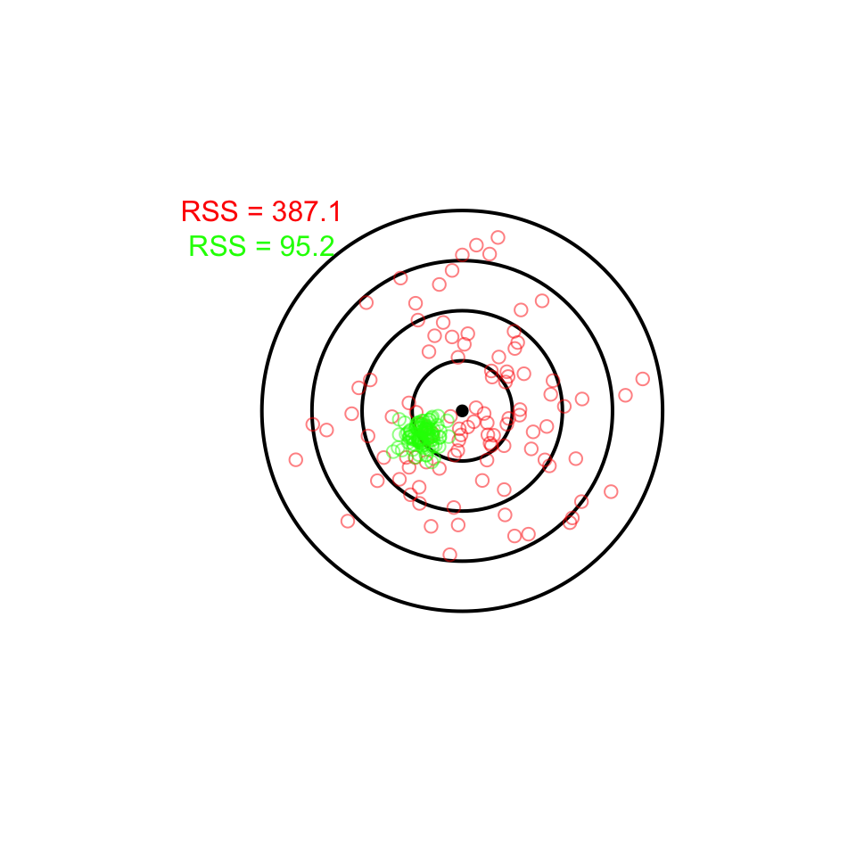

## Expected squared prediction error at a new point

$$\mathbb{E} \left[ (y - \hat{f}(x))^2 \right] =
\underbrace{\left( \mathbb{E}[\hat{f}(x)] - f(x) \right)^2}_{\text{Bias}^2} +
\underbrace{\mathbb{E} \left[ \left( \hat{f}(x) - \mathbb{E}[\hat{f}(x)] \right)^2 \right]}_{\text{Variance}} +
\underbrace{\sigma^2}_{\text{Irreducible Error}}$$

- The expected squared prediction error may be smaller for penalized regression if
  - $p$ large in comparison to $n$
    - High-dimensional data
    - Limited data
  - Irreducible error is large (low signal-to-noise ratio)
  - Presence of
    - Multicollinearity
    - Many irrelevant predictors

## Outlook and discussion

- Extensions
  - Group lasso, Adaptive lasso, smoothly clipped absolute deviation (SCAD), Horseshoe prior and more
- Hierarchical Bayes
  - Learn hyperparameters naturally from data in a Bayesian context
  - [ChatGPT](https://chatgpt.com/s/t_68ad98ec688c81918a8085332d07004e)
- Hypothesis: The frequentist rejoices at the “royalness” of ridge and lasso regression, the Bayesian says: “For me it is always that simple” – should we try more Bayesian methods?
- [Full conversation with ChatGPT](https://chatgpt.com/share/68ad968a-9784-8013-98bc-478539f4cf19)